# National Commission on Indigenous Peoples

Budget evolution and agency-level utilization, FY 2018–2026

June 2026

← All agencies

# Overview

This document profiles the budget of the **National Commission on Indigenous Peoples (NCIP)** — the agency mandated by the Indigenous Peoples’ Rights Act (IPRA) to recognize ancestral domains and serve the country’s Indigenous Peoples — across nine fiscal years, FY 2018 to FY 2026. NCIP is a very small agency, and one with a particular data constraint: usable program-level execution records were not available, so this review pairs the **proposed-to-enacted budget at the program level** with **budget utilization measured at the agency aggregate**.

Because the program-by-program execution chain cannot be traced, the emphasis here is on what NCIP’s budget is *composed of*, how Congress adjusts it, and — at the whole-agency level — how much of what is released actually gets obligated and paid out.

Three features define NCIP’s budget. First, it is **tiny relative to its mandate**: about ₱1.8B in 2026 to recognize ancestral domains spanning millions of hectares. Second, the agency has been **institutionally restless** — it moved from the Other Executive Offices to being attached to DSWD and back again within seven years, and re-cut its entire program structure in 2025, so almost every trend line in this report contains a break. Third, it is **administration- and personnel-heavy**: roughly half the 2026 budget is general management and policy/planning, and personnel services alone are 54–71% of spending in any given year.

# 1 Executive summary

**NCIP’s enacted budget has nearly doubled.** From ₱968M (2018 GAA) to ₱1,804M (2026) — about **+86% over eight years**, roughly 8% a year, and its largest enacted budget on record.

**The agency keeps moving.** NCIP sat under the **Other Executive Offices (OEOs)**, shifted **under DSWD for FY 2019–2024**, then **returned to the OEOs (FY 2025–2026)** — and adopted a **new P/A/P structure in 2025**. Every trend line below straddles these breaks.

**FY 2025 is the conspicuous exception.** Congress enacted ₱1,202M against a ₱1,600M proposal — a **−25% cut that hit every program** and zeroed out capital outlay — before FY 2026 rebounded to the record ₱1,804M.

**A people-heavy agency.** Personnel Services run **54–71% of the budget**; capital outlay is small and intermittent (₱0 in the FY 2025 GAA).

**Administration is nearly half the budget.** In FY 2026, General Management (₱435M) and Policy/Planning (₱399M) together are **46%** — almost as much as all field operations combined. Just three lines — IP Human Rights/Legal/Basic Services, General Management, and Policy/Planning — are **76%** of the budget.

> NCIP is a small, administration-heavy agency carrying an outsized mandate, whose budget has grown but been repeatedly disrupted by reorganization. With no program-level execution data, the sharpest questions are about scale versus mandate, and overhead versus delivery.

# 2 A note on the data

**Period.** FY 2018 through FY 2026 for the proposed (NEP) and enacted (GAA) budget, at the P/A/P level. Agency-level execution (Allotments, Obligations, Disbursements) covers FY 2011–2025.

**No program-level execution.** Usable **FAR No. 1** (SAAODB) records were not available for NCIP, so there is **no P/A/P-level absorption analysis**. Utilization is shown only at the **agency aggregate**.

**Two bases, not directly comparable.** The NEP/GAA figures are **current-year new appropriations only**. The execution figures are DBM’s **published agency aggregates, which combine all available funds** — new, automatic, and continuing appropriations. The two series should not be read one-to-one (for example, obligations can exceed a single year’s new appropriation because continuing funds are in play).

**Two reorganizations inside one window.** NCIP’s *mother agency* changed (OEOs → DSWD → OEOs) and its *P/A/P structure* was re-cut in 2025. Program names before and after 2025 do not line up; pre- and post-2025 program lines should be bridged with care, not compared directly.

**Expense classes.** Personnel Services (PS), Maintenance & Other Operating Expenses (MOOE), Capital Outlays (CO). NCIP carries no Financial Expenses. **Units are PHP millions** throughout (NCIP is a ₱1–2B agency).

# 3 Two reorganizations inside one budget window

Before any trend, the two structural breaks: NCIP changed mother agency twice and re-cut its programs once, all within this window.

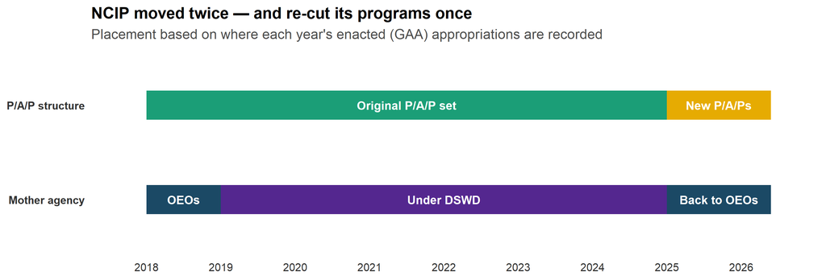

```r
tl <- tibble::tribble(
  ~track,            ~label,                ~start, ~end,   ~fill,
  "Mother agency",   "OEOs",                 2018,   2019,   "#1B4965",
  "Mother agency",   "Under DSWD",           2019,   2025,   "#54278F",
  "Mother agency",   "Back to OEOs",         2025,   2026.4, "#1B4965",
  "P/A/P structure", "Original P/A/P set",   2018,   2025,   "#1B9E77",
  "P/A/P structure", "New P/A/Ps",           2025,   2026.4, "#E6AB02")
ggplot(tl, aes(y = track)) +
  geom_segment(aes(x = start, xend = end, yend = track, color = fill), linewidth = 12, lineend = "butt") +
  scale_color_identity() +
  geom_text(aes(x = (start + end) / 2, label = label), color = "white", fontface = "bold", size = 3.6) +
  scale_x_continuous(breaks = 2018:2026, limits = c(2017.7, 2026.6)) +
  labs(title = "NCIP moved twice — and re-cut its programs once",
       subtitle = "Placement based on where each year's enacted (GAA) appropriations are recorded", x = NULL, y = NULL) +
  theme_ncip() + theme(panel.grid.major.y = element_blank(),
        axis.text.y = element_text(face = "bold", color = "grey20"))
```

Read every chart that follows with these breaks in mind — continuity of program lines is the exception here, not the rule.

# 4 The aggregate budget

## 4.1 A budget that nearly doubled

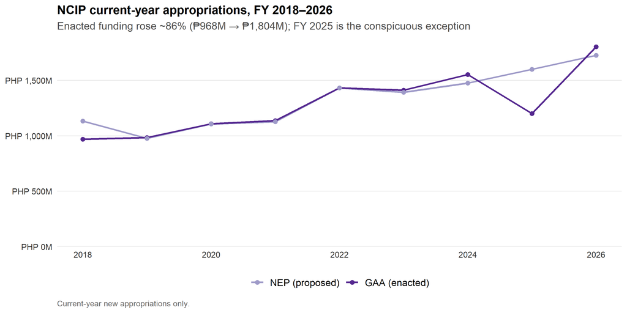

```r
evo <- totals %>% filter(metric %in% c("NEP","GAA")) %>%
  mutate(metric = factor(metric, levels = c("NEP","GAA"), labels = c("NEP (proposed)","GAA (enacted)")))
ggplot(evo, aes(year, total, color = metric, group = metric)) +
  geom_line(linewidth = 1.0) + geom_point(size = 2) +
  scale_color_manual(values = exec_pal) +
  scale_y_continuous(labels = php_m_axis, breaks = pretty_breaks(6), limits = c(0, NA), expand = expansion(mult = c(0, .05))) +
  scale_x_continuous(breaks = seq(2018, 2026, 2)) +
  labs(title = "NCIP current-year appropriations, FY 2018–2026",
       subtitle = "Enacted funding rose ~86% (₱968M → ₱1,804M); FY 2025 is the conspicuous exception",
       x = NULL, y = NULL, caption = "Current-year new appropriations only.") +
  theme_ncip() + guides(color = guide_legend(nrow = 1))
```

The budget grew steadily through the DSWD years (FY 2019–2024 GAA rose ~9–10% a year), dropped sharply in FY 2025, then rebounded to a record in FY 2026. The proposed (NEP) and enacted (GAA) lines track closely in most years — Congress generally stays within a few percent of the proposal — with two exceptions: 2018 (−15%) and 2025 (−25%).

```r
totals %>% filter(metric %in% c("NEP","GAA")) %>% mutate(value = total/1e6) %>%
  select(year, metric, value) %>% pivot_wider(names_from = year, values_from = value) %>%
  mutate(metric = factor(metric, levels = c("NEP","GAA"))) %>% arrange(metric) %>% rename(`PHP M` = metric) %>%
  kbl_clean(font = 13, digits = 0, format.args = list(big.mark = ","), na = "")
```

| PHP M | 2018 | 2019 | 2020 | 2021 | 2022 | 2023 | 2024 | 2025 | 2026 |
| --- | --- | --- | --- | --- | --- | --- | --- | --- | --- |
| NEP | 1,132 | 977 | 1,107 | 1,127 | 1,432 | 1,393 | 1,476 | 1,600 | 1,727 |
| GAA | 968 | 985 | 1,110 | 1,137 | 1,432 | 1,413 | 1,553 | 1,202 | 1,804 |

## 4.2 Where Congress adjusts the budget

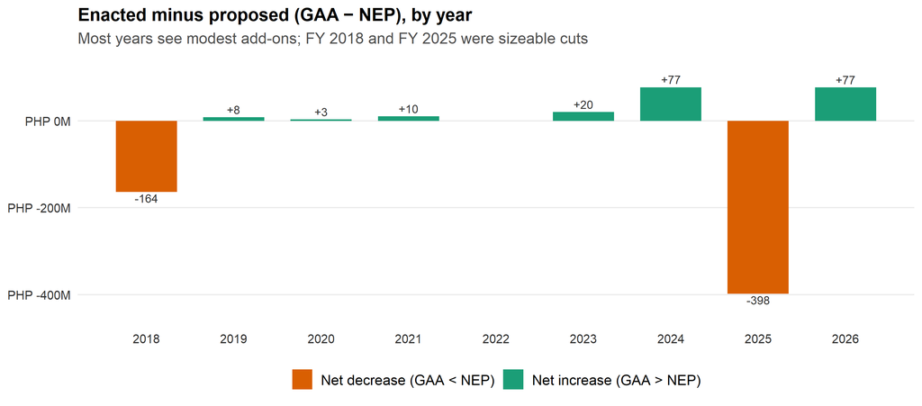

```r
gap <- totals %>% filter(metric %in% c("NEP","GAA")) %>% pivot_wider(names_from = metric, values_from = total) %>%
  mutate(change = GAA - NEP, direction = ifelse(change >= 0, "Net increase (GAA > NEP)", "Net decrease (GAA < NEP)"))
ggplot(gap, aes(year, change/1e6, fill = direction)) +
  geom_col(width = 0.7) +
  geom_text(aes(label = ifelse(abs(change) < 1e6, "", sprintf("%+.0f", change/1e6)),
                vjust = ifelse(change >= 0, -0.4, 1.2)), size = 3.2, color = "grey20") +
  scale_fill_manual(values = c("Net increase (GAA > NEP)" = "#1B9E77", "Net decrease (GAA < NEP)" = "#D95F02")) +
  scale_x_continuous(breaks = 2018:2026) +
  scale_y_continuous(labels = function(v) paste0(peso, v, "M"), expand = expansion(mult = c(0.16, 0.16))) +
  labs(title = "Enacted minus proposed (GAA − NEP), by year",
       subtitle = "Most years see modest add-ons; FY 2018 and FY 2025 were sizeable cuts", x = NULL, y = NULL) +
  theme_ncip() + guides(fill = guide_legend(nrow = 1))
```

In most years Congress trims or tops up the proposal only modestly. The exception that matters is **FY 2025**, when the enacted budget came in ₱398M (−25%) below the proposal.

## 4.3 The FY 2025 cut hit everything

```r
df_long %>% filter(year == 2025, metric %in% c("NEP","GAA")) %>%
  group_by(category, metric) %>% summarise(v = sum(amount, na.rm = TRUE)/1e6, .groups = "drop") %>%
  pivot_wider(names_from = metric, values_from = v) %>% filter(!(is.na(NEP) & is.na(GAA))) %>%
  mutate(Cut = GAA - NEP, `Cut %` = scales::percent(Cut/NEP, accuracy = 1)) %>% arrange(desc(NEP)) %>%
  transmute(`Program (2025 structure)` = category, NEP = round(NEP), GAA = round(GAA), Cut = round(Cut), `Cut %`) %>%
  kbl_clean(font = 13, align = "lrrrr", format.args = list(big.mark = ","), na = "") %>%
  column_spec(4:5, color = "#D95F02")
```

| Program (2025 structure) | NEP | GAA | Cut | Cut % |
| --- | --- | --- | --- | --- |
| IP Governance & Empowerment (2025-) | 443 | 407 | -37 | -8% |
| General Administration and Support | 411 | 296 | -115 | -28% |
| Support to Operations | 369 | 246 | -123 | -33% |
| Domain/Land Recognition & Dev’t (2025-) | 199 | 112 | -86 | -43% |
| IP Human Rights, Legal & Basic Svcs (2025-) | 141 | 110 | -32 | -23% |
| IP Cultural Services (2025-) | 36 | 31 | -5 | -13% |
| Ancestral Domain Recognition (2018-24) | 0 | 0 | 0 |  |
| Rights, Legal & Adjudication (2018-24) | 0 | 0 | 0 |  |
| Socio-economic & Cultural Services (2018-24) | 0 | 0 | 0 |  |

# 5 Where the money goes

## 5.1 Composition by PREXC program

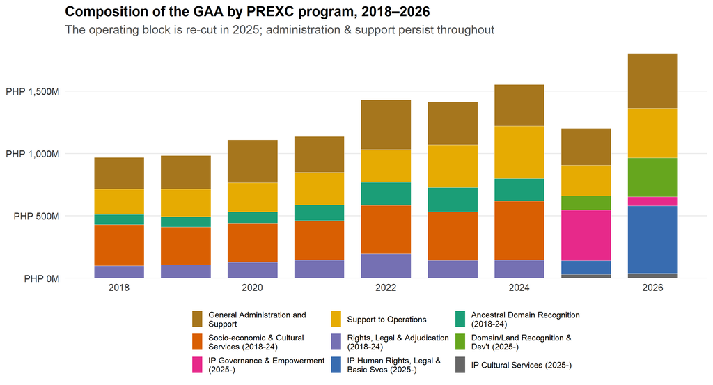

```r
comp <- df_long %>% filter(metric == "GAA", year <= 2026, !is.na(amount), !is.na(category)) %>%
  group_by(year, category) %>% summarise(amount = sum(amount, na.rm = TRUE), .groups = "drop") %>%
  mutate(category = factor(category, levels = names(cat_pal)))
ggplot(comp, aes(year, amount, fill = category)) +
  geom_col(width = 0.75, color = "white", linewidth = 0.2) +
  scale_fill_manual(values = cat_pal, labels = function(x) str_wrap(x, 28)) +
  scale_y_continuous(labels = php_m_axis, breaks = pretty_breaks(6), limits = c(0, NA), expand = expansion(mult = c(0, .05))) +
  scale_x_continuous(breaks = seq(2018, 2026, 2)) +
  labs(title = "Composition of the GAA by PREXC program, 2018–2026",
       subtitle = "The operating block is re-cut in 2025; administration & support persist throughout", x = NULL, y = NULL) +
  theme_ncip() + guides(fill = guide_legend(nrow = 3, byrow = TRUE)) +
  theme(legend.text = element_text(size = 8.5), legend.key.size = unit(0.38, "cm"))
```

## 5.2 Composition by expense class

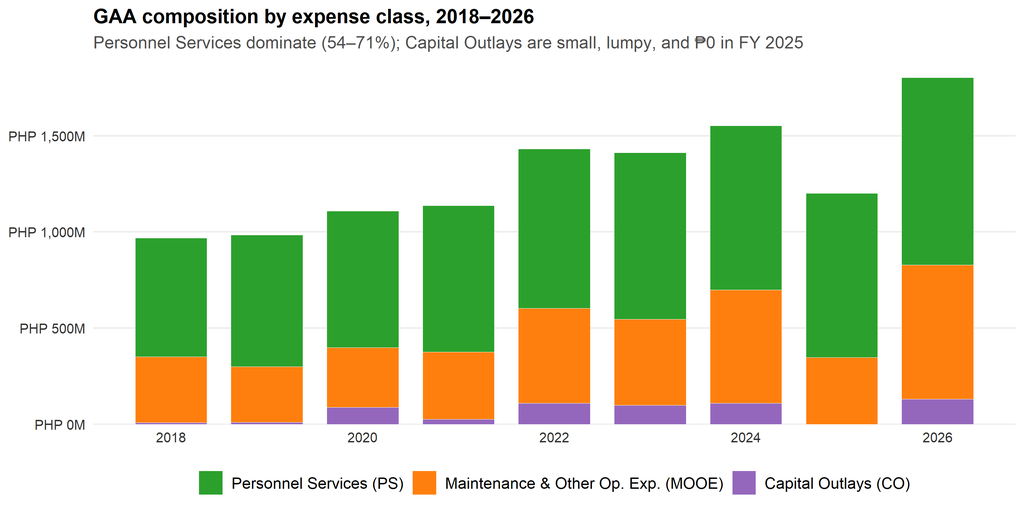

```r
ec_levels <- c("Personnel Services (PS)","Maintenance & Other Op. Exp. (MOOE)","Capital Outlays (CO)")
comp_ec <- df_long_all %>% filter(metric == "GAA", year <= 2026, expense_class %in% c("1PS","2MOOE","6CO")) %>%
  group_by(year, expense_class) %>% summarise(amount = sum(amount, na.rm = TRUE), .groups = "drop") %>%
  mutate(expense_class = factor(expense_class, levels = c("1PS","2MOOE","6CO"), labels = ec_levels))
ggplot(comp_ec, aes(year, amount, fill = expense_class)) +
  geom_col(width = 0.75, color = "white", linewidth = 0.2) +
  scale_fill_manual(values = ec_pal) +
  scale_y_continuous(labels = php_m_axis, breaks = pretty_breaks(6), limits = c(0, NA), expand = expansion(mult = c(0, .05))) +
  scale_x_continuous(breaks = seq(2018, 2026, 2)) +
  labs(title = "GAA composition by expense class, 2018–2026",
       subtitle = "Personnel Services dominate (54–71%); Capital Outlays are small, lumpy, and ₱0 in FY 2025", x = NULL, y = NULL) +
  theme_ncip() + guides(fill = guide_legend(nrow = 1))
```

NCIP is a payroll-and-operations agency: **Personnel Services are 54–71% of the budget every year**, MOOE the bulk of the rest, and **Capital Outlays small, lumpy, and absent entirely from the FY 2025 GAA**. For an agency whose mandate is field-intensive — delineating and titling ancestral domains — the near-absence of capital spending is itself notable.

```r
comp_ec %>% group_by(year) %>% mutate(share = round(amount/sum(amount)*100)) %>% ungroup() %>%
  select(expense_class, year, share) %>% pivot_wider(names_from = year, values_from = share) %>%
  rename(`Expense class (% of GAA)` = expense_class) %>% kbl_clean(font = 12.5, na = "")
```

| Expense class (% of GAA) | 2018 | 2019 | 2020 | 2021 | 2022 | 2023 | 2024 | 2025 | 2026 |
| --- | --- | --- | --- | --- | --- | --- | --- | --- | --- |
| Personnel Services (PS) | 64 | 70 | 64 | 67 | 58 | 61 | 55 | 71 | 54 |
| Maintenance & Other Op. Exp. (MOOE) | 35 | 29 | 28 | 31 | 34 | 32 | 38 | 29 | 39 |
| Capital Outlays (CO) | 1 | 1 | 8 | 2 | 8 | 7 | 7 | 0 | 7 |

## 5.3 The largest P/A/Ps

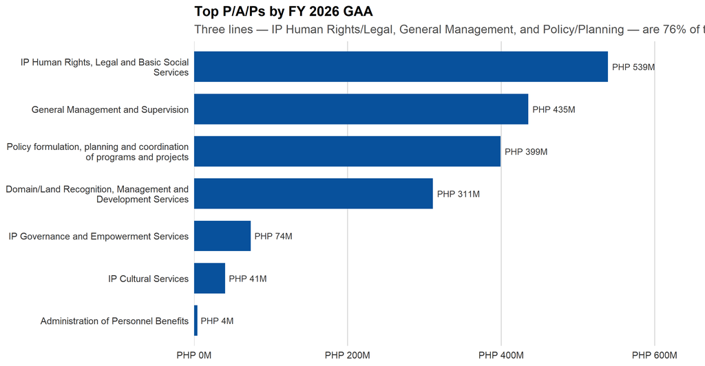

```r
top_paps <- pap_year %>% filter(year == 2026, !is.na(GAA), GAA > 0) %>% arrange(desc(GAA)) %>%
  slice_head(n = 10) %>% mutate(pap = factor(pap, levels = rev(pap)))
ggplot(top_paps, aes(pap, GAA)) +
  geom_col(fill = bar_fill, width = 0.72) +
  geom_text(aes(label = php_m(GAA)), hjust = -0.1, size = 3.2, color = "grey20") +
  coord_flip() + scale_x_discrete(labels = function(x) str_wrap(x, 46)) +
  scale_y_continuous(labels = php_m_axis, expand = expansion(mult = c(0, .22)), limits = c(0, NA)) +
  labs(title = "Top P/A/Ps by FY 2026 GAA",
       subtitle = "Three lines — IP Human Rights/Legal, General Management, and Policy/Planning — are 76% of the budget",
       x = NULL, y = NULL) +
  theme_ncip() + theme(panel.grid.major.y = element_blank(), panel.grid.major.x = element_line(color = "grey85"))
```

The concentration is striking for a commission with a broad field mandate: the single largest line is **IP Human Rights, Legal and Basic Social Services (₱539M)**, followed immediately by two overhead lines — **General Management (₱435M)** and **Policy formulation and planning (₱399M)**. Ancestral **Domain/Land Recognition** — arguably the core IPRA function — is fourth at ₱311M.

```r
tibble::tibble(
  `Original operating programs (≤ 2024)` = c("Ancestral Domain Recognition", "Socio-economic & Cultural Services",
    "Rights, Legal & Adjudication", "", ""),
  `Restructured operating programs (2025 →)` = c("Domain/Land Recognition, Management & Development",
    "IP Governance & Empowerment Services", "IP Human Rights, Legal & Basic Social Services",
    "IP Cultural Services", "")) %>%
  kbl_clean(font = 13, align = "ll", na = "",
            caption = "How the operating side was re-cut in 2025 (three programs → four)")
```

How the operating side was re-cut in 2025 (three programs → four)

| Original operating programs (≤ 2024) | Restructured operating programs (2025 →) |
| --- | --- |
| Ancestral Domain Recognition | Domain/Land Recognition, Management & Development |
| Socio-economic & Cultural Services | IP Governance & Empowerment Services |
| Rights, Legal & Adjudication | IP Human Rights, Legal & Basic Social Services |
|  | IP Cultural Services |

The operating side was reorganized from **three programs into four**, around domain/land, governance & empowerment, human rights/legal/basic services, and culture. The two support programs — General Administration & Support and Support to Operations — carry through both regimes unchanged.

### Full P/A/P ranking, FY 2026 (interactive)

```r
pap_year %>% filter(year == 2026, !is.na(GAA)) %>%
  left_join(pap_year %>% filter(year == 2025) %>% transmute(pap, GAA25 = GAA), by = "pap") %>%
  transmute(`P/A/P` = pap, `NEP 2026 (M)` = NEP/1e6, `GAA 2026 (M)` = GAA/1e6,
            `GAA 2025 (M)` = GAA25/1e6, `Net chg 2026 (M)` = (GAA - NEP)/1e6) %>%
  arrange(desc(`GAA 2026 (M)`)) %>%
  dt_table(page = 10, money_cols = c("NEP 2026 (M)","GAA 2026 (M)","GAA 2025 (M)","Net chg 2026 (M)"))
```

| P/A/P | NEP 2026 (M) | GAA 2026 (M) | GAA 2025 (M) | Net chg 2026 (M) |
| --- | --- | --- | --- | --- |
| IP Human Rights, Legal and Basic Social Services | 556.083 | 539.145 | 109.544 | -16.938 |
| General Management and Supervision | 435.359 | 435.359 | 289.608 | 0 |
| Policy formulation, planning and coordination of programs and projects | 399.267 | 399.267 | 246.103 | 0 |
| Domain/Land Recognition, Management and Development Services | 217.089 | 310.979 | 112.449 | 93.89 |
| IP Governance and Empowerment Services | 73.807 | 73.807 | 406.563 | 0 |
| IP Cultural Services | 40.572 | 40.572 | 31.089 | 0 |
| Administration of Personnel Benefits | 4.448 | 4.448 | 6.242 | 0 |

# 6 Overall budget utilization

With no program-level execution data, utilization can only be read at the **agency aggregate** — and on a different basis from the appropriations above (all available funds, not just current-year new appropriations). On that basis NCIP is a strong absorber.

## 6.1 Execution over time

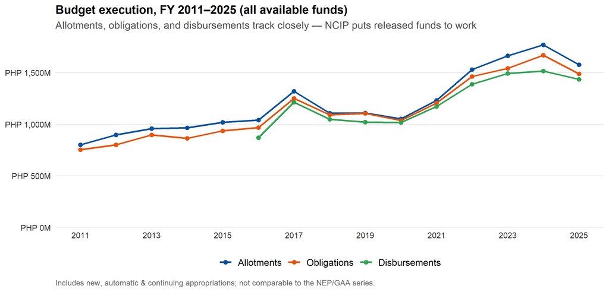

```r
el <- exec %>% select(year, Allotments, Obligations, Disbursements) %>%
  pivot_longer(-year, names_to = "stage", values_to = "amount") %>% filter(!is.na(amount)) %>%
  mutate(stage = factor(stage, levels = c("Allotments","Obligations","Disbursements")))
ggplot(el, aes(year, amount, color = stage, group = stage)) +
  geom_line(linewidth = 1.0) + geom_point(size = 2) +
  scale_color_manual(values = exec_pal) +
  scale_y_continuous(labels = php_m_axis, breaks = pretty_breaks(6), limits = c(0, NA), expand = expansion(mult = c(0, .05))) +
  scale_x_continuous(breaks = seq(2011, 2025, 2)) +
  labs(title = "Budget execution, FY 2011–2025 (all available funds)",
       subtitle = "Allotments, obligations, and disbursements track closely — NCIP puts released funds to work",
       x = NULL, y = NULL, caption = "Includes new, automatic & continuing appropriations; not comparable to the NEP/GAA series.") +
  theme_ncip() + guides(color = guide_legend(nrow = 1))
```

The three lines sit close together across fifteen years: what is released is, for the most part, obligated and paid.